# A Survey of Red Wine Factors by Tyler Barbian

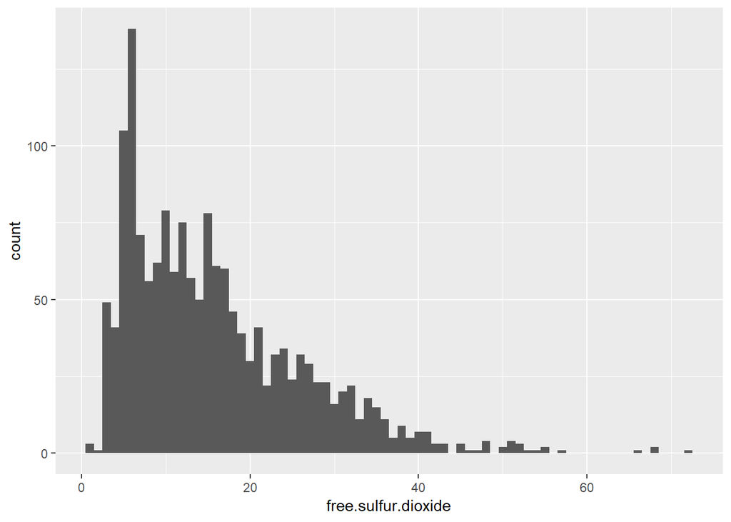

It looks like free sulfur dioxide has a much narrower presence than total, which makes sense because it’s a proportion of total. It’s also skewed right.

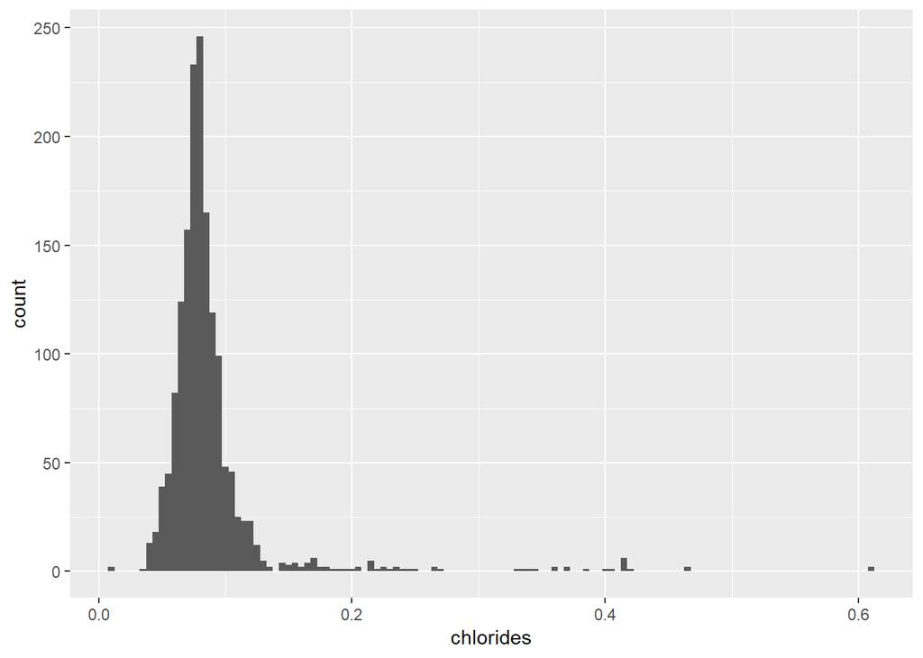

It looks like most wines have .1 chlorides. It dorps significantly at .125, but theres a number of outliers that contiunue out to .6

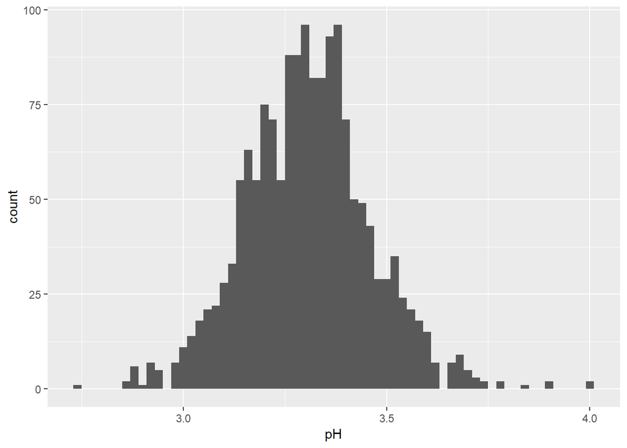

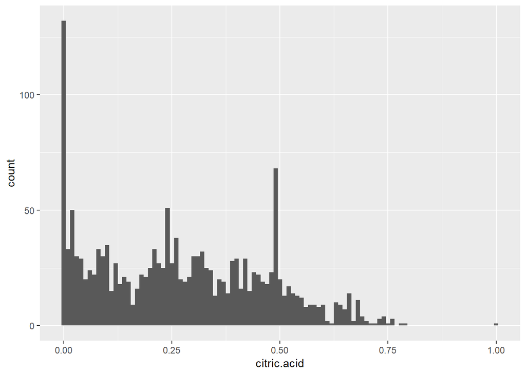

It looks like a lot of wines dont have any citric acid, and the rest have a variety of concentrations with another peak at .48.

```
##    Mode   FALSE    TRUE
## logical    1467     132
```

Checking to see which wines have 0 citric acid, we see its 132, compared to 1467 that contain citric acid.

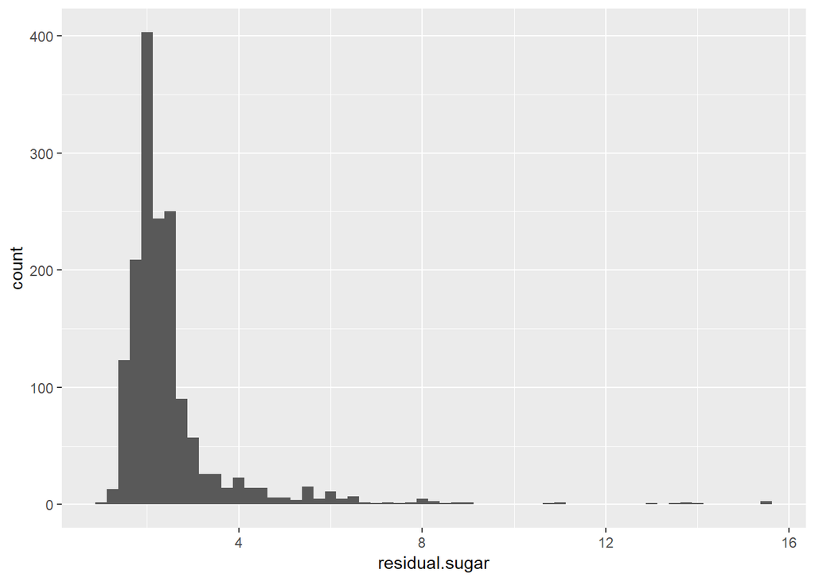

A majority of wines have less than 3 sugar, with a skew to the right.

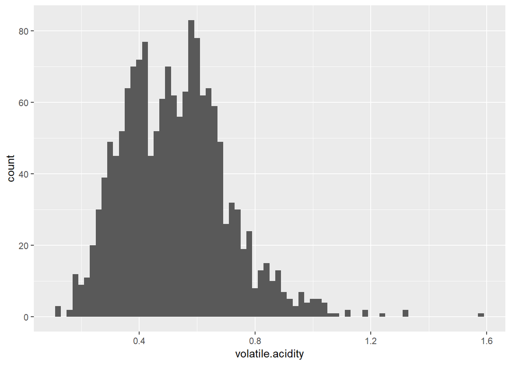

Volatile acidity resembles a nomral curve with a skew to the right. I wonder if the middle would more closely resemble a normal curve with more observations.

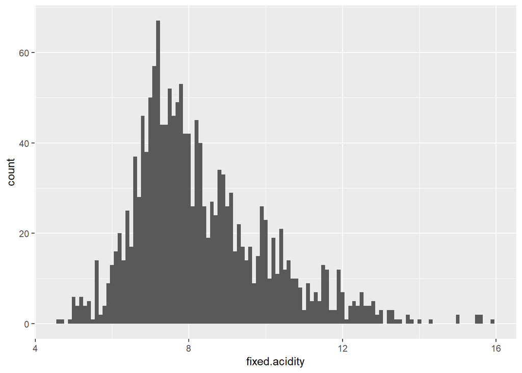

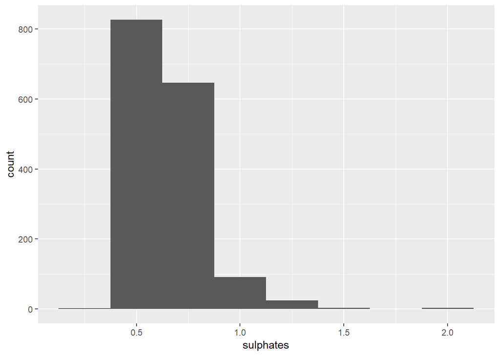

# Univariate Analysis

The data set contains 1599 different red wines with 13 features. The Main feature of interest is the quality of red wines. It isn’t yet clear which features of the wine most affect quality. Knowing little about wine, I’m predicting the 3 measures of acidity have an impact on quality, as well as the residual sugar content.

# Bivariate Plots Section

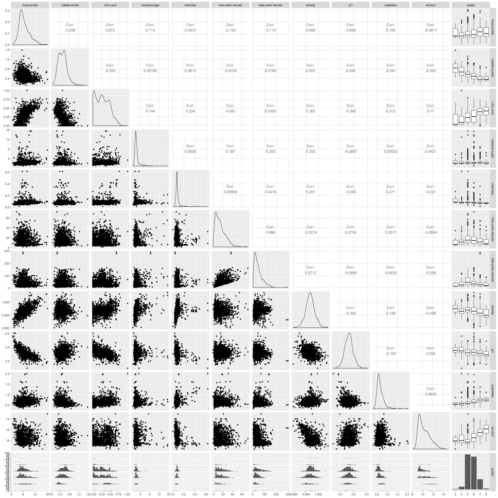

Few pairs have a correlation higer than .5. The pairing of pH and fixed.acidity and the pairing of citric acid and fixed acidity both surpass .65. Since they are different measures of acidity, this makes sense. Fixed acidity and denisty have a higher correlation as well, passing the .65 level. Finally, free sulfur dioxides and total sulfur dioxides have a strong correlation.

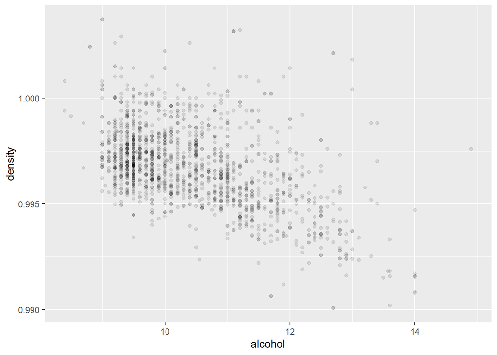

There seems to be a negative correlation between alcohol and density.

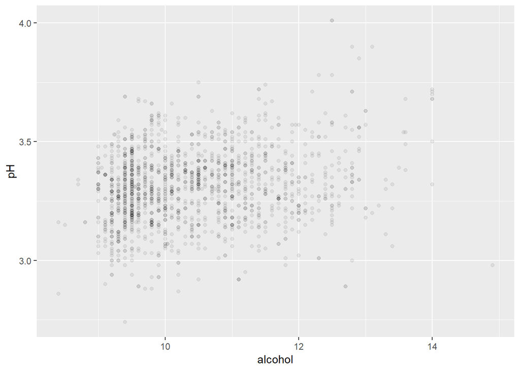

Alcohol and pH don’t seem to have any significant trends or correlation.

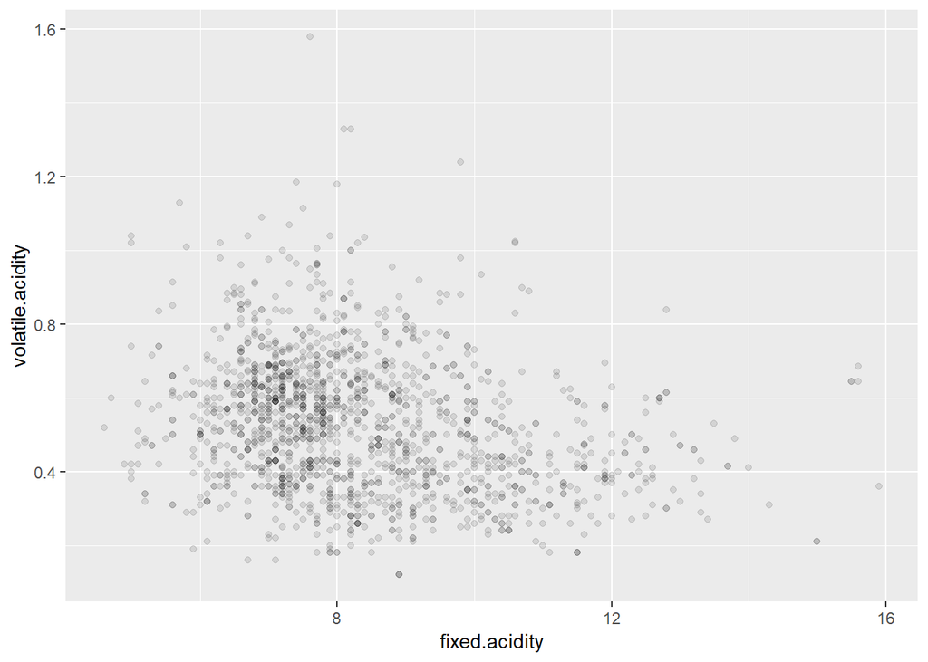

Volatile Acidity and fixed acidity don’t seem to have any correlation.

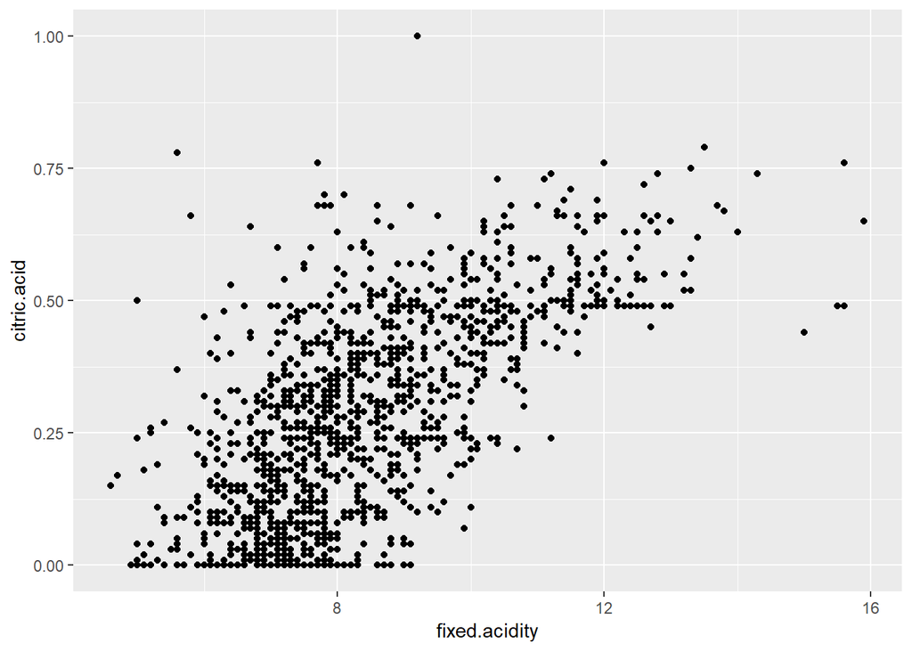

This comparison looks an awful lot like a square root function.

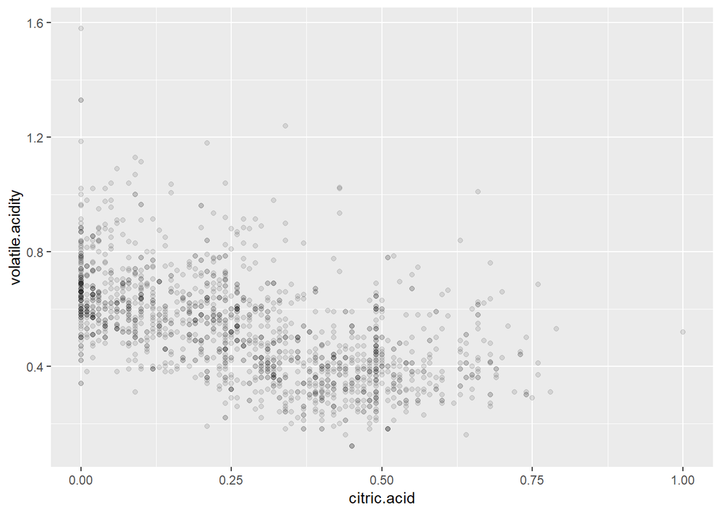

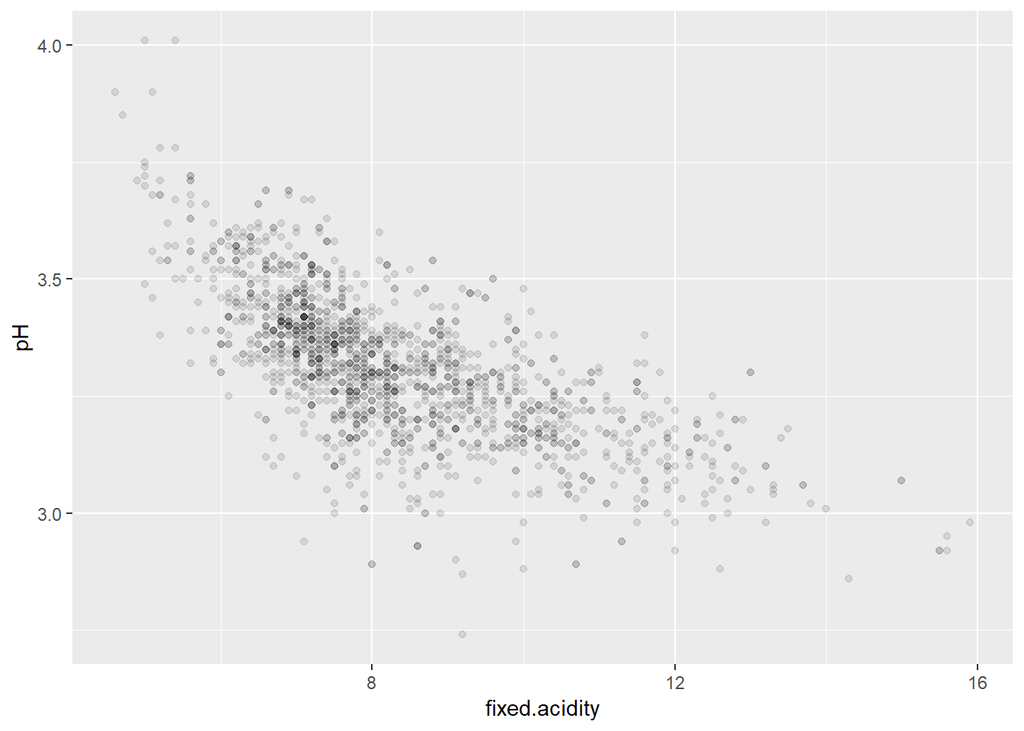

This looks like it needs a log transformation.

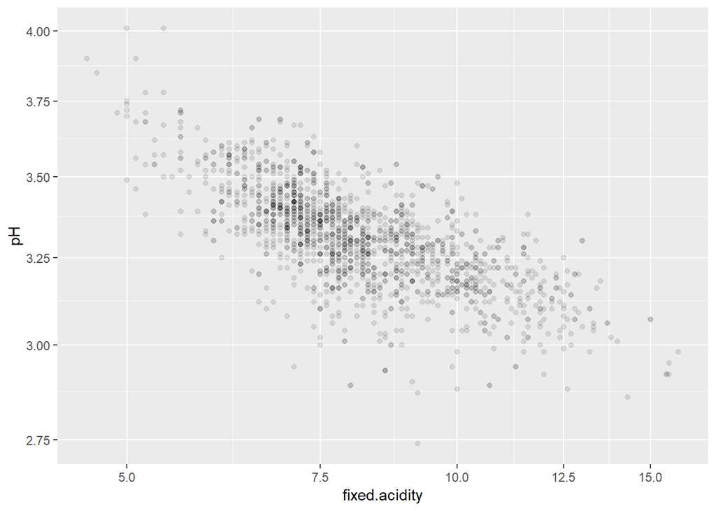

Looks like there’s a negative correlation between fixed.acidity and pH. Which makes sense because pH is a measure of acididity.

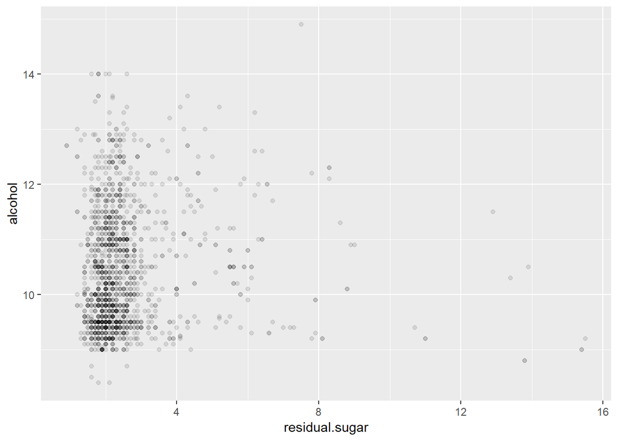

Alcohol and Residual Sugar don’t seem to have any correlation.

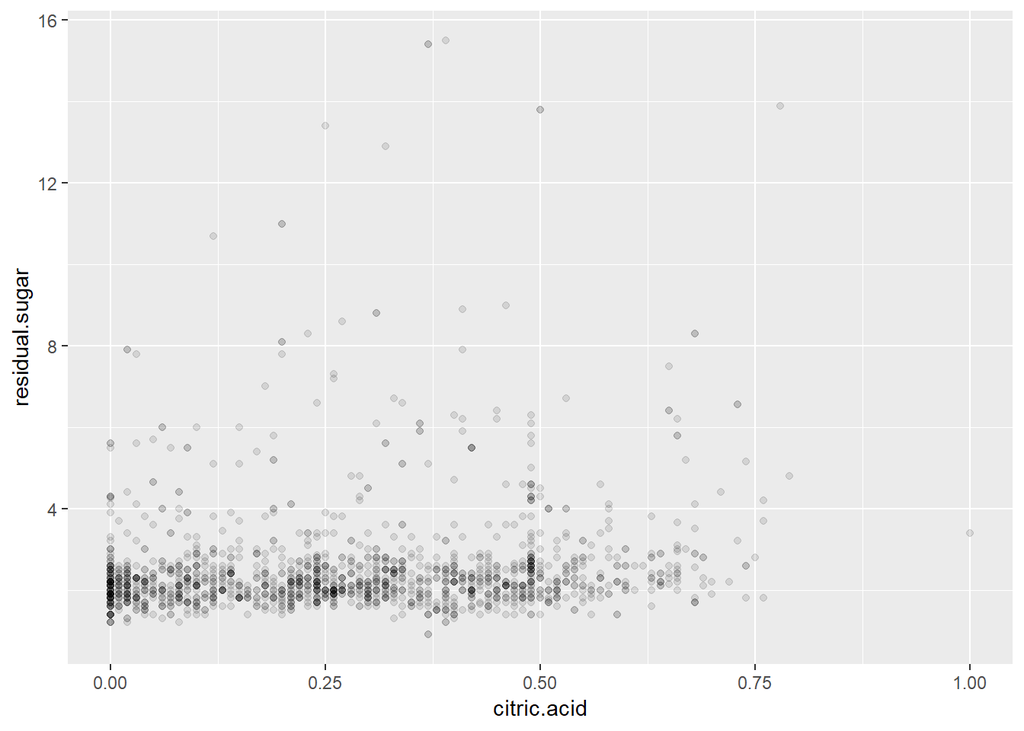

There doesn’t isn’t much pattern between residual sugar and citric acid either.

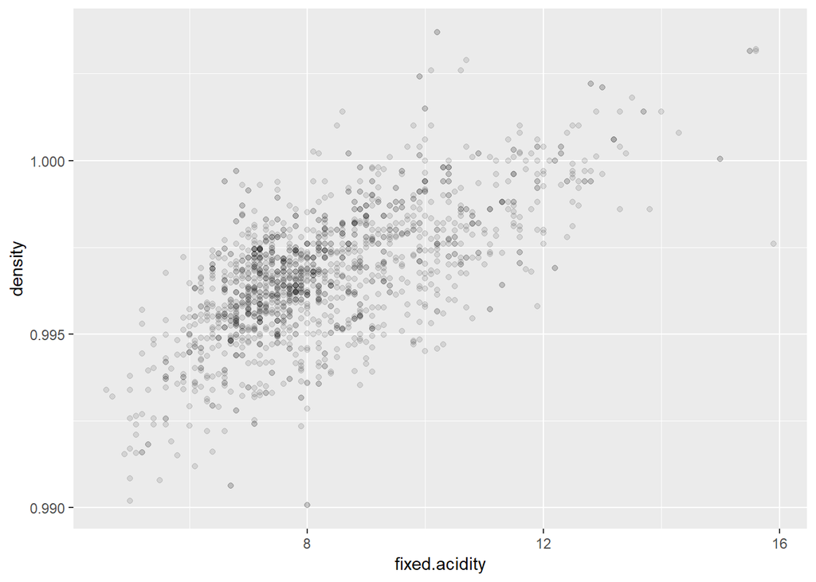

There seems to be a pretty strong correlation between fixed.acidity and density. Since alcohol and fixed acidity make pretty distinct graphs with density, maybe they have something going on between them?

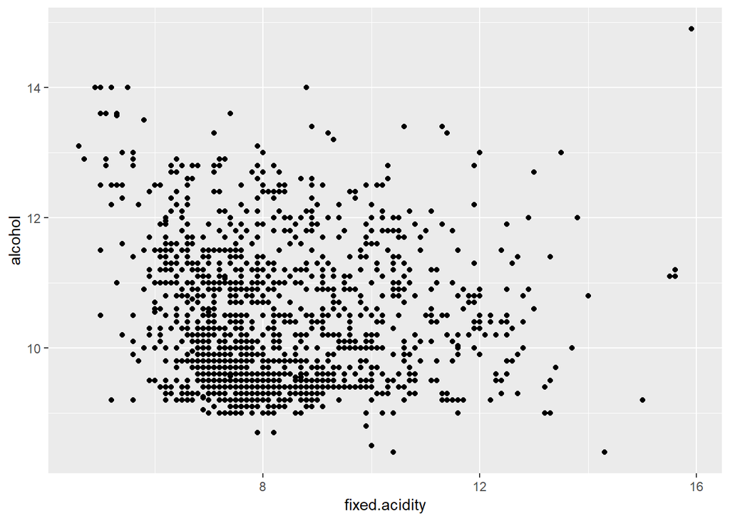

All over the board. We will table this idea for now.

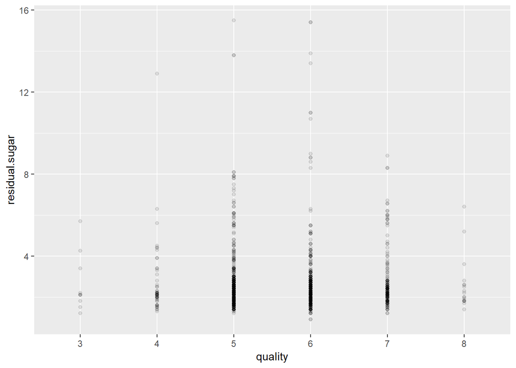

Interesting. Residual sugar plotted against Quality resembles a normal curve.

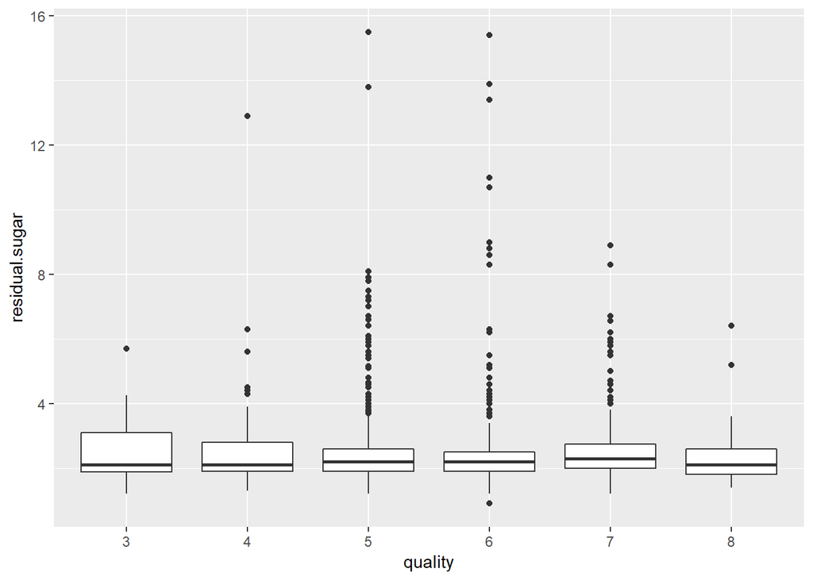

It looks like theres a lot of residual quality outliers in residual sugar. The means are all relatively close to each other, indicating there isn’t as much effect as the first graph would imply.

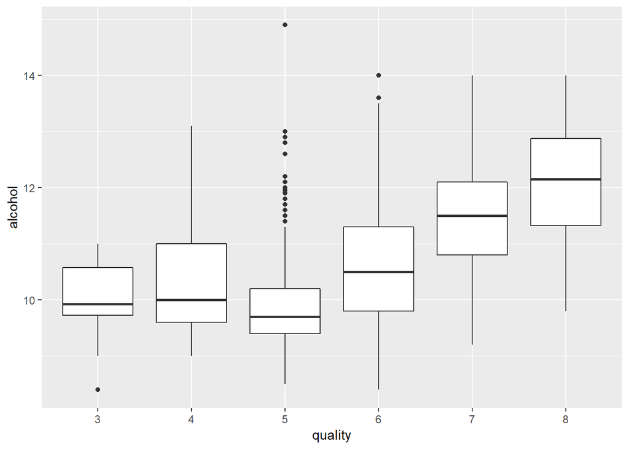

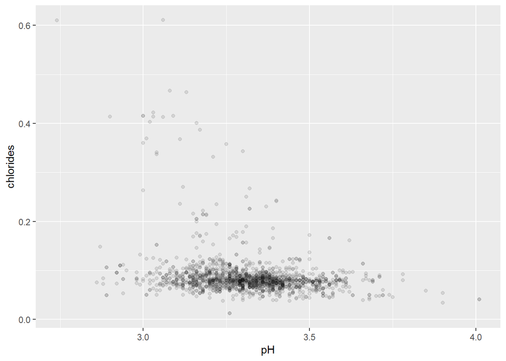

Chlorides don’t seem to have any particular effect on pH.

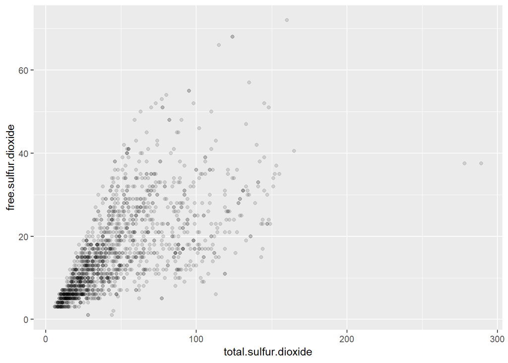

This looks like a potential correlation, after some sort of transformation.

# Bivariate Analysis

The interesting plots between variables tended to have specific shapes to them, such as citric acid vs volatile acidity. The less interesting plots tended to be blobs without any clear shape. The residual sugar compared to quality plots were very intersting. The scatter plot makes it look like a normal distribution, when the means really are pretty even across the board as show by the box plot. Most of the acidities are related, which isn’t surprising. The relationship between alcohol and density is intersting. Maybe alcohol isn’t as dense as water? I think overall the strongest relationship was between fixed acidity and pH.